# Covid-19 Hospitalizations in Belgium

Jean-Michel Bodart

Fri Jun 12 21:34:43 2020

Purpose: provide an overview of the evolution of Covid-19-related hospitalizations in Belgium, by Region and Province.

## Source Data Sets

### COVID19BE_HOSP (HOSPITALISATIONS BY DATE AND PROVINCE)

Source: https://epistat.sciensano.be/Data/20200612/COVID19BE_HOSP_20200612.csv

Data last modified: 2020-06-11 16:17:45 GMT.

Dataset [description](https://epistat.sciensano.be/COVID19BE_codebook.pdf).

#### Source Variables

| Variable | Definition |
| --- | --- |
| DATE | Date of data collection |
| PROVINCE | Province of reporting hospitals (including Brussels) |
| REGION | Region of reporting hospitals |
| NR_REPORTING | Number of hospitals reporting |
| TOTAL_IN | Total number of hospitalized patients at the moment of reporting (prevalence) |
| TOTAL_IN_ICU | Total number of hospitalized patients in ICU at the moment of reporting (prevalence) |
| TOTAL_IN_RESP | Total number of hospitalized patients under respiratory support at the moment of reporting (prevalence) |
| TOTAL_IN_ECMO | Total number of hospitalized patients on ECMO (Extracorporeal Membrane Oxygenation) at the moment of reporting (prevalence) |
| NEW_IN | Number of new hospital intakes in the last 24h (incidence) |
| NEW_OUT | Number of new hospital discharges (alive) in the last 24h (incidence) |

#### Newly Derived Variables

| Variable | Definition |
| --- | --- |
| Full_reporting | Whether the number of hospitals reporting is equal to the maximal number of hospitals reporting |
| TOTAL_IN_CHG | (Total number of hospitalized patients at the moment of reporting) - (Total number of hospitalized patients the previous day) |
| NEW_DELTA | (Number of new hospital intakes) - (new hospital discharges (alive) in the last 24h) |

Source code: [Github](https://github.com/jmbo1190/Covid19)

Summarized data: csv json

### Belgium Population by Province

Source: Official data from https://bestat.statbel.fgov.be/bestat/

C01.1: Population par lieu de résidence (province), sexe, position dans le ménage (C), état civil et âge (B)

[csv](https://bestat.statbel.fgov.be/bestat/api/views/0f14f470-9a59-4011-ac98-92ebe2df31ff/result/CSV) [json](https://bestat.statbel.fgov.be/bestat/api/views/0f14f470-9a59-4011-ac98-92ebe2df31ff/result/JSON)

## Revision History

#### 2020-04-15 - Added Belgium Population Data by Province

Added link to Source Code

Added Figures for:

- Number of Patients Hospitalized per Million Inhabitants by Province
- Number of Patients in Intensive Care per Million Inhabitants by Province
- Number of Patients under Respiratory Support per Million Inhabitants by Province

#### 2020-04-13 - Updated to include Figures by Province

As shown below, the evolution is *not identical* in all provinces.

- **As of April 13th:**
  - The total number hospitalized is still on the rise in the province of Namur.
  - The numbers in intensive care are increasing in the provinces of Namur and Oost-Vlaanderen.
  - The numbers of patients under extracorporeal membrane oxygenation are still on a rising trend in all provinces except Vlaams Brabant, West-Vlaanderen, Liège and Brabant Wallon.

### Daily Admissions, Discharges and Changes in Total Number of Patients Hospitalized over Belgium and by Region

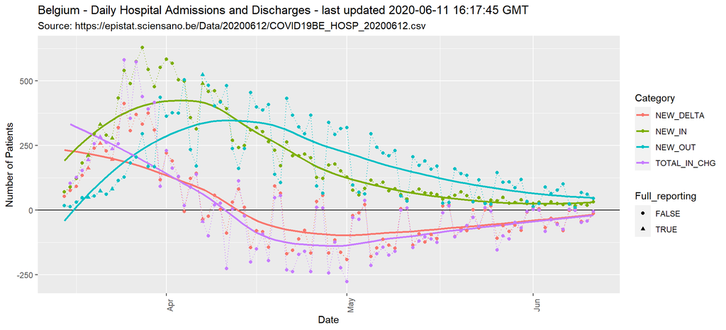

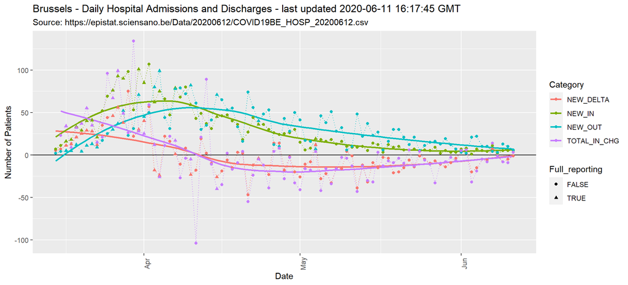

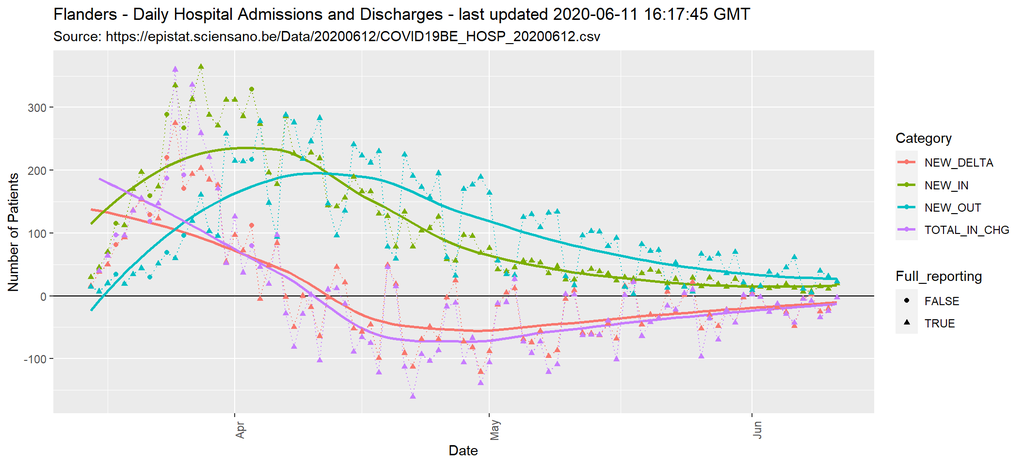

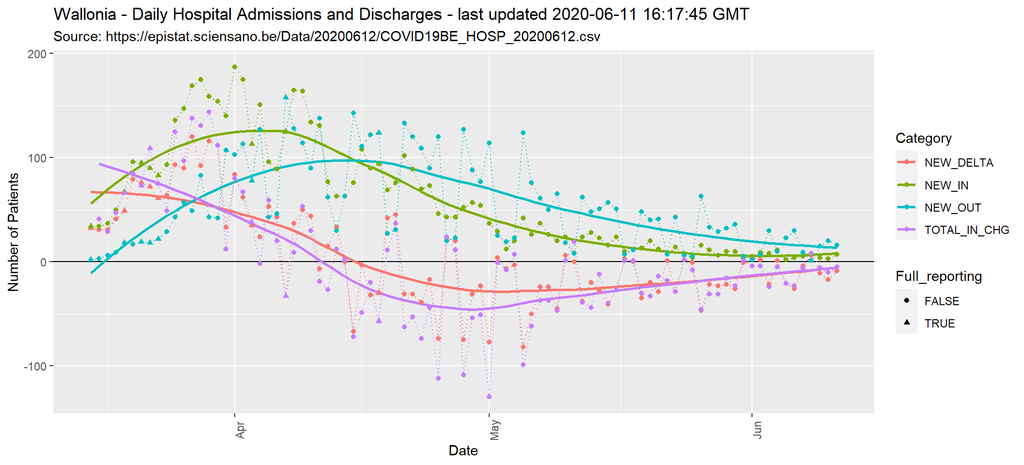

### Daily Admissions, Discharges and Changes in Total Number of Patients Hospitalized by Province

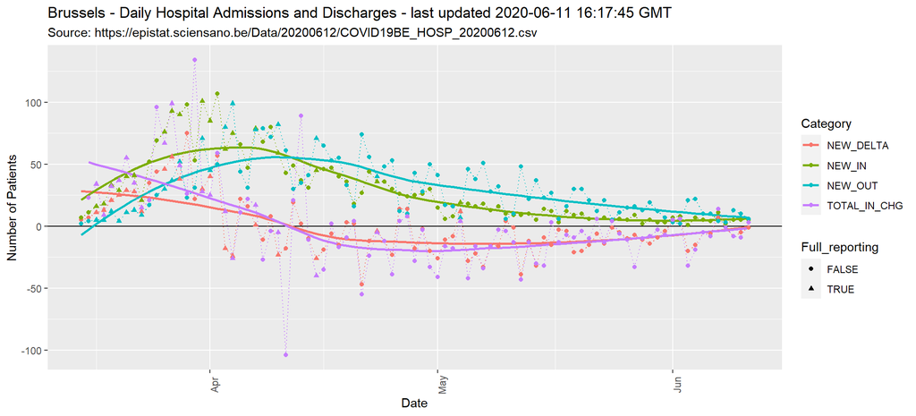

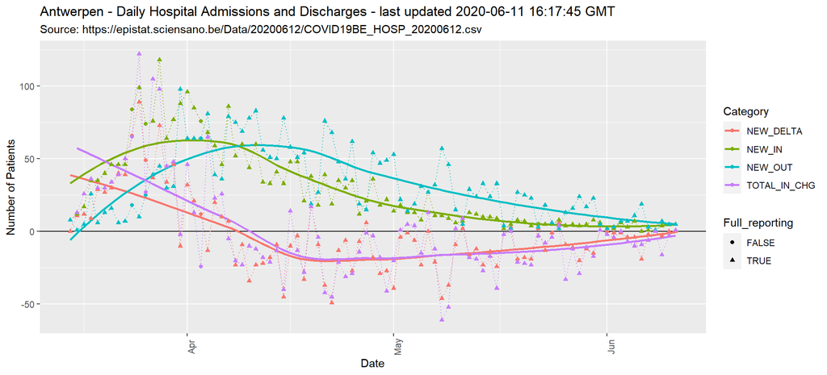

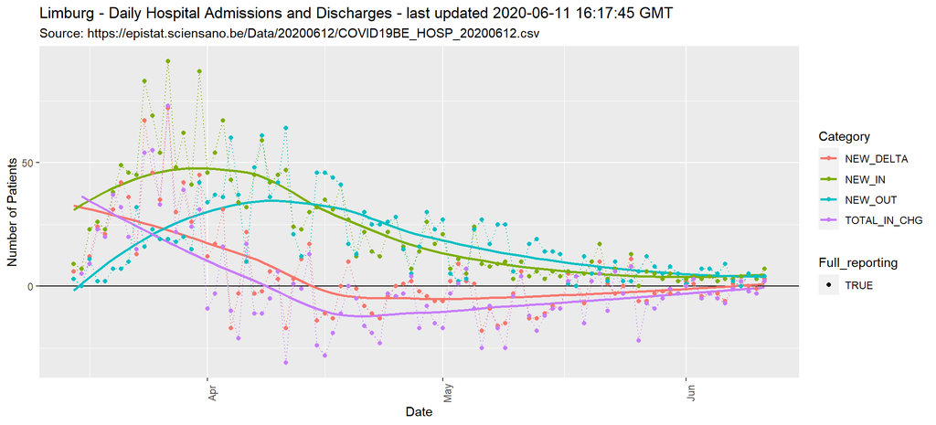

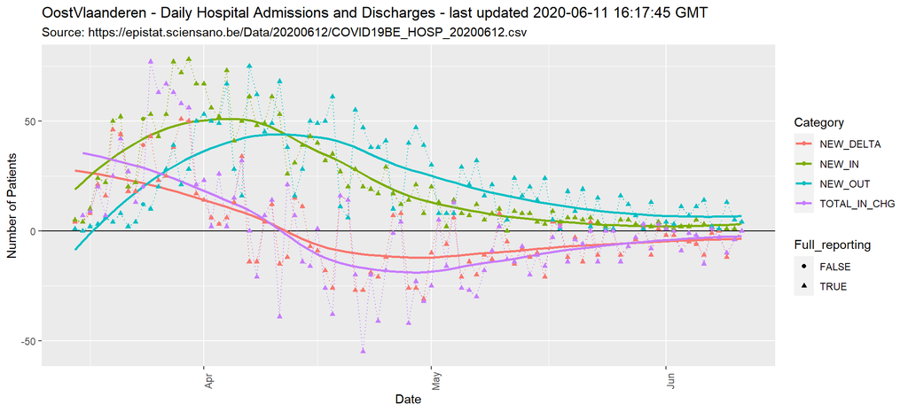

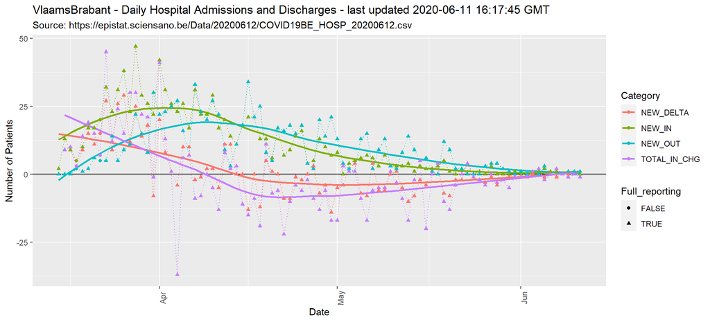

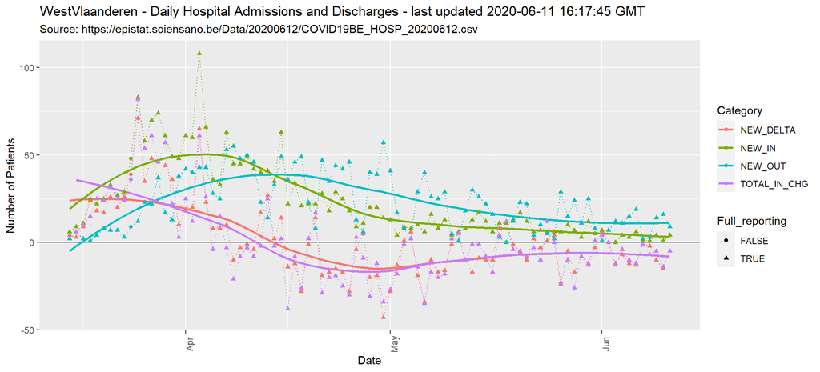

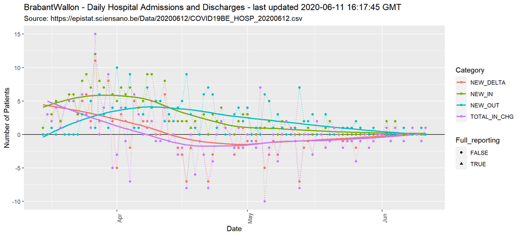

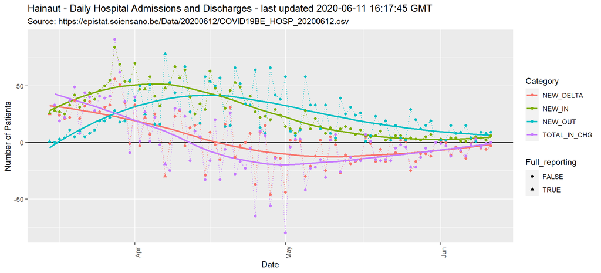

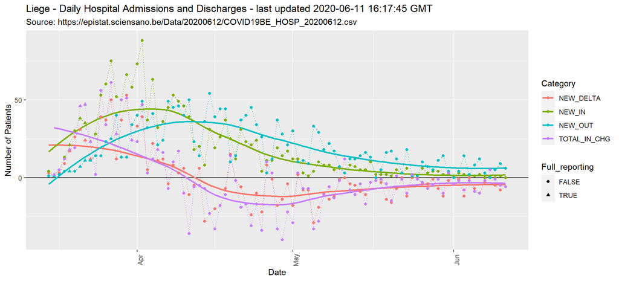

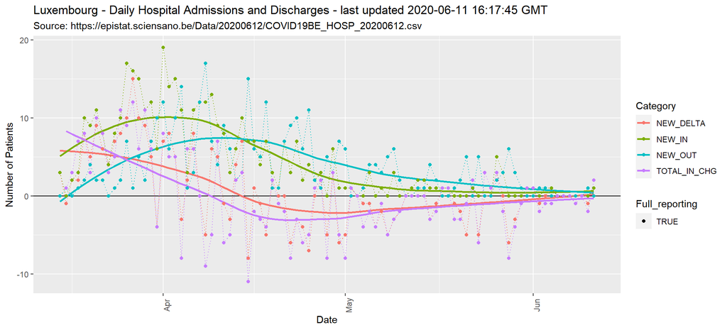

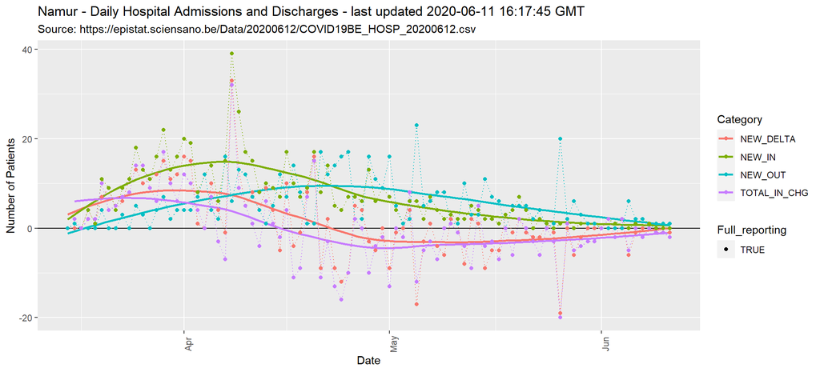

### Number of Patients Hospitalized in Belgium and by Region

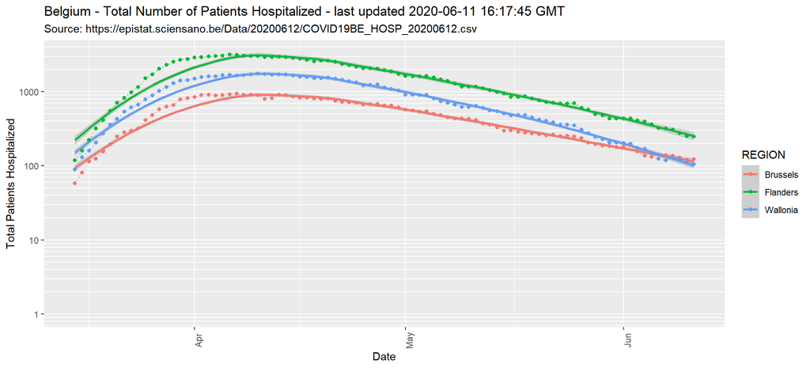

[figure not shown]

### Number of Patients Hospitalized in Belgium by Province

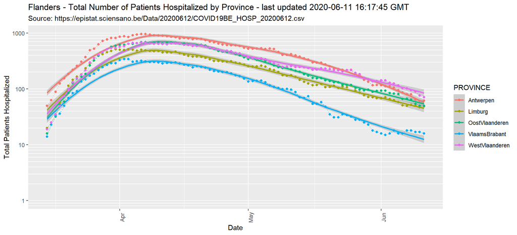

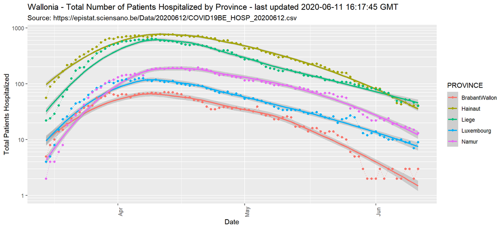

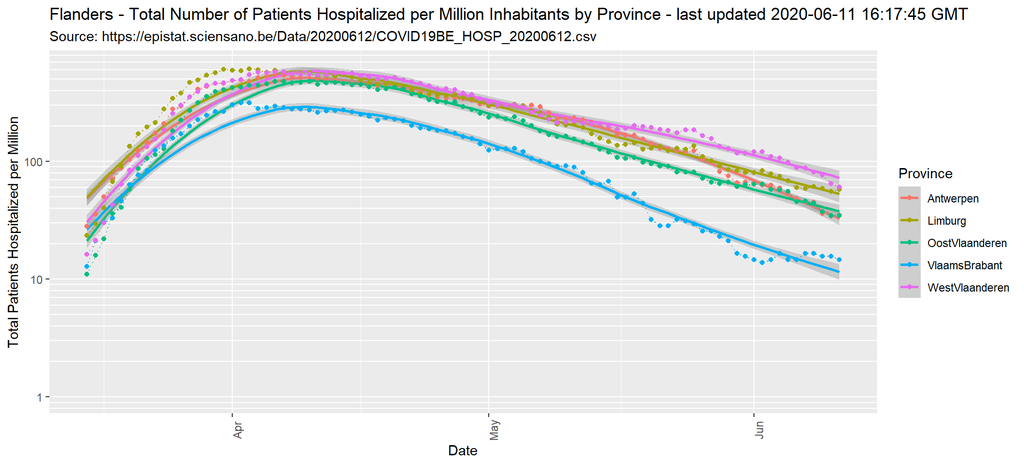

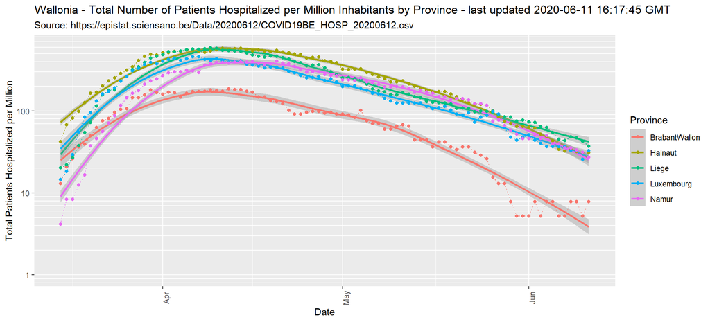

### Number of Patients In Intensive Care in Belgium by Region

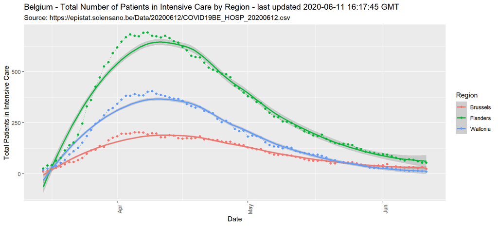

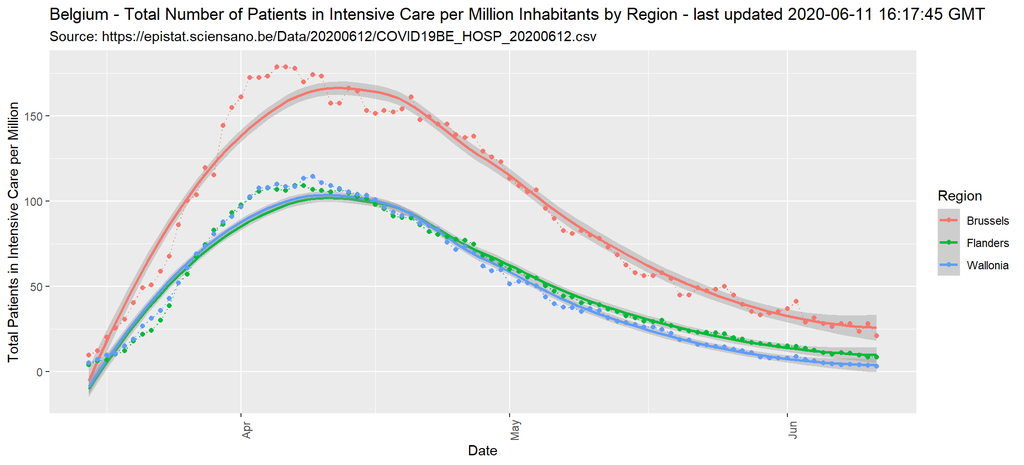

### Number of Patients In Intensive Care in Belgium by Province

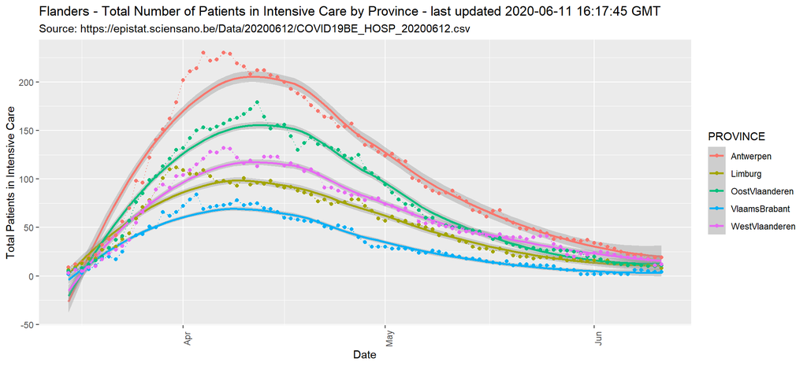

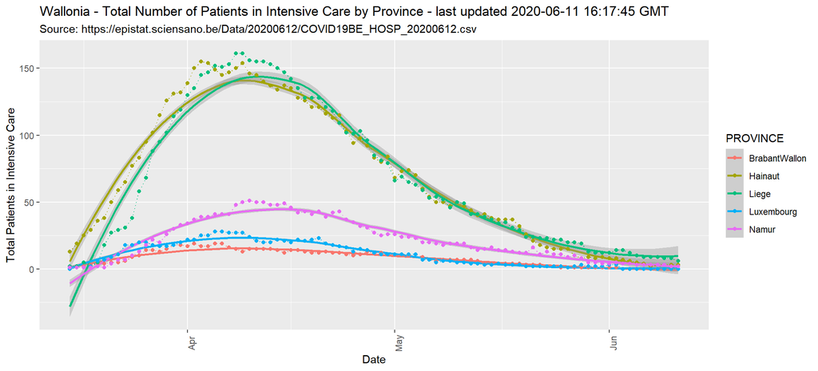

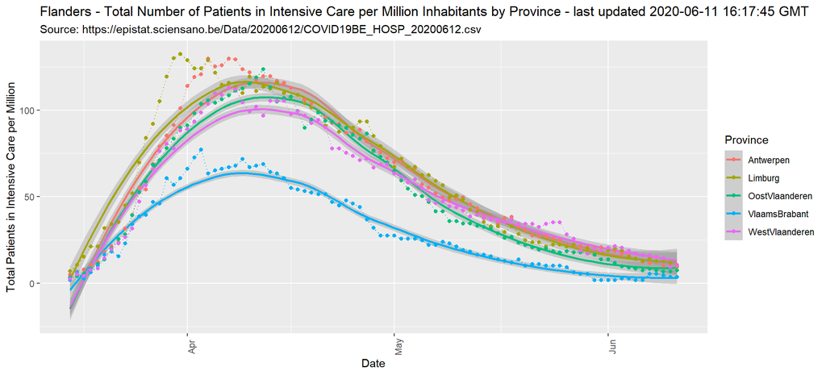

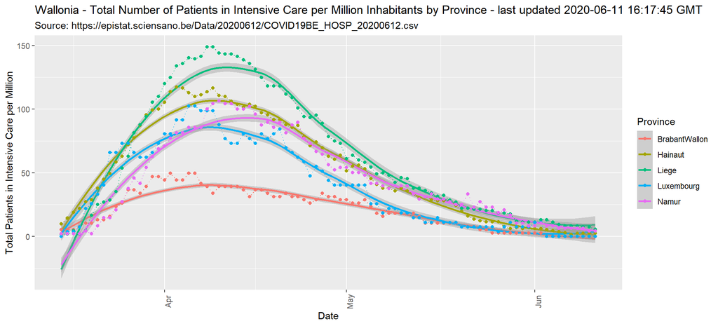